# Mass Balance models

# Equifinality

## Uncertainty analysis

In this lecture we are going to learn about an essential step in modelling with scientific rigour. Conducting an uncertainty analysis.

When we model the world, we are trying to estimate what would be the parameters of our models in the real world.

However, one of the problems is that estimation always comes associated with statistical errors. We almost never can say for sure how the world actually behaves, however, we can calculate our probability of being wrong every time we make an statement about the world. Doing so, requires us to understand the level of uncertainty of our models.

First let’s understand why it is important, given what we already know.

## Understanding equifinality

Equifinality means that, when modelling the world, we can reach multiple sets of parameters that seems reasonably similar to the “real-world” set of parameters. To understand this let’s artificially create a “real-world” scenario.

```r
# Let's create a "real world" system - a simple lake with unknown parameters
true_params <- c(
  k = 0.03,        # Decay rate (1/day) - UNKNOWN!
  C_in=5           # # Inflow concentration (mg/L) - UNKOWN
    )

state=c(
C=2
)

# Creates the model of the system
cstr_model <- function(time,state, parameters) {
  with(as.list(c(state, parameters)), {
    V = 10000      # Volume (m³) - known
    Q = 10        # Flow (m³/day) - known

    dC_dt <- (Q*C_in)/V - (Q*C)/V - k*C
    return(list(c(dC_dt)))
  })
}

# Run the real system to steady state
times <- seq(0, 100, by = 1)
true_output <- ode(y = state, times = times,
                   func = cstr_model, parms = true_params)
true_output_df <- as.data.frame(true_output)
```

So we created a model with outputs without errors. That is impossible to have when trying to understand our world.

**Sources of Uncertainty:**

1. **Parameter uncertainty** - We don’t know the true values.
2. **Structural uncertainty** - Our model might be wrong (maybe decay isn’t first-order?)
3. **Scenario uncertainty** - Future conditions might be different
4. **Observation uncertainty** - Our measurements have error

In this example, let’s introduce errors associated with observation and sampling.

### Introducing measurement errors

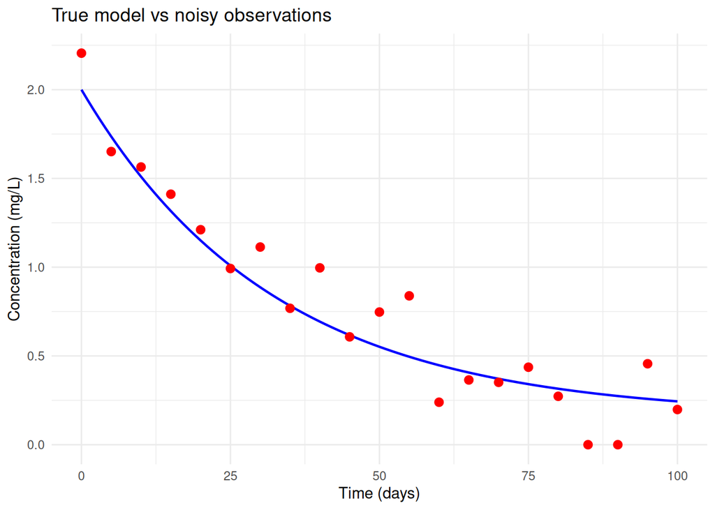

```r
set.seed(42)

# Add measurement error to create our "observations"
observations <- true_output_df %>%
  filter(time %% 5  == 0) %>%  # Sample every 5 days
  mutate(C_obs = pmax(0, C + rnorm(n(), 0, 0.15)))  # Observation error SD = 0.15 mg/L

# Plot the observations
ggplot() +
  geom_line(data = true_output_df, aes(x = time, y = C),
            colour = "blue", linewidth = 0.8) +
  geom_point(data = observations, aes(x = time, y = C_obs),
             colour = "red", size = 2.5) +
  labs(title = "True model vs noisy observations",
       x = "Time (days)", y = "Concentration (mg/L)") +
  theme_minimal()
```

### Estimating parameters

Now, if this was a real experiment, we would have our noisy observations and we know the best model to predict the system described as `cstr_model`

What would the next step be?

```r
initial_guesses = c(k = 0.05, C_in = 4) # provide initial guesses for the estimated parameters

error_function_cstr <- function(parameters, time, data) {
  out <- as.data.frame(ode(y = state["C"],
                           times = data$time,
                           func = cstr_model,
                           parms = parameters))

  C_error <- sum((out[,2]-data$C_obs)^2, na.rm = TRUE)

  return(C_error)
}

result <- optim(
  par = initial_guesses,            # Starting point
  fn = error_function_cstr,              # Function to minimize
  data = observations,       # Additional arguments to error_function
  method = "Nelder-Mead",           # Optimization algorithm
  control = list(maxit = 1000)      # Settings
)

cat("Estimated k:", result$par["k"], "\n")
```

```
## Estimated k: 0.02115746
```

```r
cat("Estimated C_in:", result$par["C_in"], "\n")
```

```
## Estimated C_in: -1.515047
```

```r
cat("True k:", true_params["k"], "  True C_in:", true_params["C_in"], "\n")
```

```
## True k: 0.03   True C_in: 5
```

```r
predicted_sample<-as.data.frame(ode(y = state["C"], times = observations$time,
                      func = cstr_model, parms = result$par))
```

Plot the model optimized to your data in the chunk below and save to the graph `equifinality_plot`

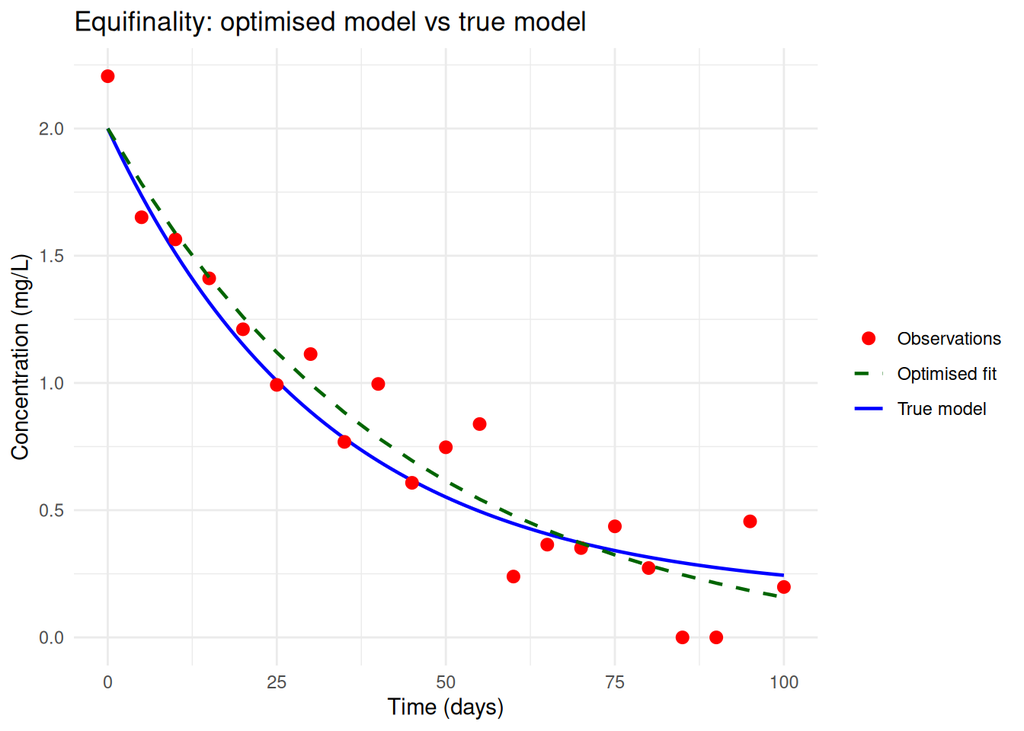

```r
predicted1<-predicted_sample$C

equifinality_plot <- ggplot() +
  geom_line(data = true_output_df, aes(x = time, y = C, colour = "True model"),
            linewidth = 0.8) +
  geom_point(data = observations, aes(x = time, y = C_obs, colour = "Observations"),
             size = 2.5) +
  geom_line(data = data.frame(time = observations$time, C = predicted1),
            aes(x = time, y = C, colour = "Optimised fit"),
            linewidth = 0.8, linetype = "dashed") +
  scale_colour_manual(values = c("True model" = "blue",
                                 "Observations" = "red",
                                 "Optimised fit" = "darkgreen")) +
  labs(title = "Equifinality: optimised model vs true model",
       x = "Time (days)", y = "Concentration (mg/L)", colour = "") +
  theme_minimal()

equifinality_plot
```

If this is based on the same real-world model, why are all the models not the same?

### Resampling your data.

```r
initial_guesses = c(k =.03 , C_in=5 ) # provide initial guesses for the estimated parameters

rs_sample<-300

rs_parameters<-data.frame(k = numeric(rs_sample), C_in = numeric(rs_sample))

for(i in 1:rs_sample)
{
rs_observations <- true_output_df %>%
  filter(time %% 5  == 0) %>%  # Sample every 5 days
  mutate(C_obs = pmax(0, C + rnorm(n(), 0, 0.15)))  # Same observation error


result_rs <- optim(
  par = initial_guesses,            # Starting point
  fn = error_function_cstr,              # Function to minimize
  data = rs_observations,       # Additional arguments to error_function
  method = "Nelder-Mead",           # Optimization algorithm
  control = list(maxit = 1000)      # Settings
)
rs_parameters[i,1] <- result_rs$par[1]
rs_parameters[i,2] <- result_rs$par[2]

if (i %% 50 == 0) cat("Iteration", i, "of", rs_sample, "\n")
}
```

```
## Iteration 50 of 300
## Iteration 100 of 300
## Iteration 150 of 300
## Iteration 200 of 300
## Iteration 250 of 300
## Iteration 300 of 300
```

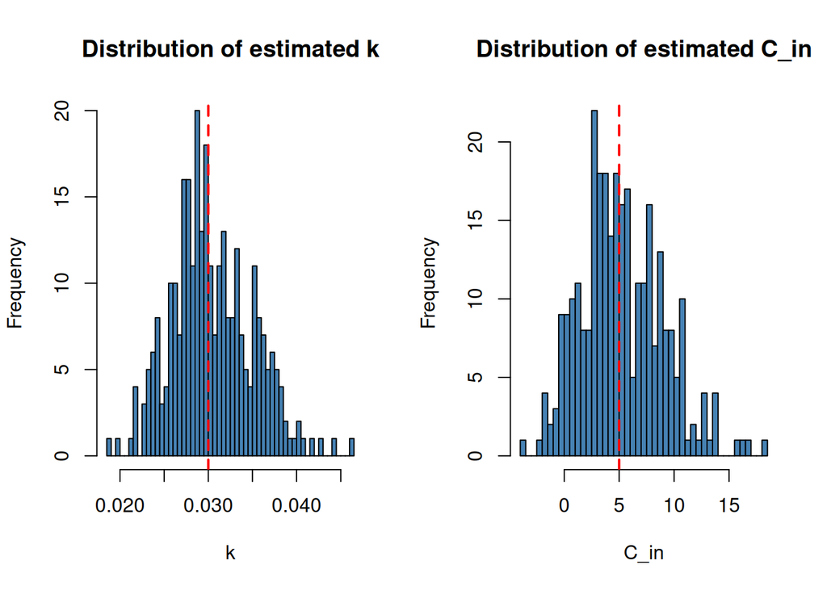

```r
par(mfrow = c(1, 2))
hist(rs_parameters$k, breaks = 40, col = "steelblue",
     main = "Distribution of estimated k", xlab = "k")
abline(v = true_params["k"], col = "red", lwd = 2, lty = 2)

hist(rs_parameters$C_in, breaks = 40, col = "steelblue",
     main = "Distribution of estimated C_in", xlab = "C_in")
abline(v = true_params["C_in"], col = "red", lwd = 2, lty = 2)
```

```r
par(mfrow = c(1, 1))
```

# MCMC

## Metropolis-Hastings Implementation

```r
# -----------------------------------------------------------------------------
# Simple Metropolis-Hastings MCMC Implementation
# -----------------------------------------------------------------------------

known_params <- c(
  V = 1000,      # Lake volume (m³)
  Q = 50,        # Inflow/outflow rate (m³/day)
  C_in=5
)

# We'll implement a simple Metropolis-Hastings algorithm
# This helps students understand the mechanics before using packages

metropolis_mcmc <- function(
    n_iter = 10000,           # Number of iterations
    initial_k = 0.3,          # Starting value
    proposal_sd = 0.05,       # Proposal step size
    observations,              # Data
    known_params,              # Known parameters
    prior_range = c(0.01, 1)  # Prior range for k
) {

  # Storage for chain
  chain <- data.frame(
    iteration = 1:n_iter,
    k = NA,
    log_likelihood = NA,
    accepted = FALSE
  )

  # Initialize
  current_k <- initial_k
  current_params <- c(known_params, k = current_k)

  # Calculate initial likelihood
  out <- ode(y = c(C = observations$C_obs[1]),
             times = observations$time,
             func = cstr_model,
             parms = current_params)
  out_df <- as.data.frame(out)

  # Log-likelihood (assuming normal errors)
  errors <- observations$C_obs - out_df$C
  current_loglik <- -length(errors)/2 * log(2*pi) -
                    0.5 * sum((errors/0.2)^2)  # Assume SD = 0.2

  chain[1, ] <- c(1, current_k, current_loglik, TRUE)

  # MCMC loop
  for (i in 2:n_iter) {
    # Propose new k
    proposed_k <- rnorm(1, current_k, proposal_sd)

    # Check prior bounds
    if (proposed_k >= prior_range[1] && proposed_k <= prior_range[2]) {

      # Run model with proposed k
      proposed_params <- c(known_params, k = proposed_k)
      out <- ode(y = c(C = observations$C_obs[1]),
                 times = observations$time,
                 func = cstr_model,
                 parms = proposed_params)
      out_df <- as.data.frame(out)

      # Calculate log-likelihood
      errors <- observations$C_obs - out_df$C
      proposed_loglik <- -length(errors)/2 * log(2*pi) -
                         0.5 * sum((errors/0.2)^2)

      # Metropolis acceptance ratio
      log_ratio <- proposed_loglik - current_loglik

      if (log(runif(1)) < log_ratio) {
        # Accept
        current_k <- proposed_k
        current_loglik <- proposed_loglik
        accepted <- TRUE
      } else {
        # Reject
        accepted <- FALSE
      }
    } else {
      # Outside prior - reject automatically
      accepted <- FALSE
      proposed_loglik <- -Inf
    }

    # Store
    chain[i, ] <- c(i, current_k, current_loglik, accepted)
  }

  return(chain)
}

# Run MCMC
n_iter <- 10000
mcmc_chain <- metropolis_mcmc(
  n_iter = n_iter,
  initial_k = 0.3,
  proposal_sd = 0.03,
  observations = observations,
  known_params = known_params
)

# Calculate acceptance rate
acceptance_rate <- mean(mcmc_chain$accepted)
cat("MCMC Acceptance rate:", round(100 * acceptance_rate, 1), "%\n")
```

```
## MCMC Acceptance rate: 8.9 %
```

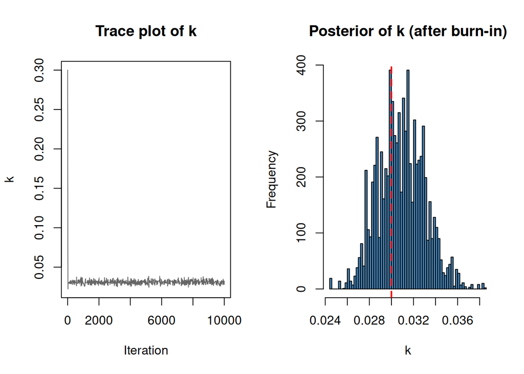

```r
# --- Diagnostics ---
par(mfrow = c(1, 2))
plot(mcmc_chain$iteration, mcmc_chain$k, type = "l",
     xlab = "Iteration", ylab = "k", main = "Trace plot of k", col = "grey40")
burnin <- 2001
hist(mcmc_chain$k[burnin:n_iter], breaks = 50, col = "steelblue",
     main = "Posterior of k (after burn-in)", xlab = "k")
abline(v = true_params["k"], col = "red", lwd = 2, lty = 2)
```

```r
par(mfrow = c(1, 1))

cat("Posterior mean k:", mean(mcmc_chain$k[burnin:n_iter]), "\n")
```

```
## Posterior mean k: 0.03091898
```

```r
cat("95% credible interval:",
    quantile(mcmc_chain$k[burnin:n_iter], c(0.025, 0.975)), "\n")
```

```
## 95% credible interval: 0.02715831 0.03528808
```

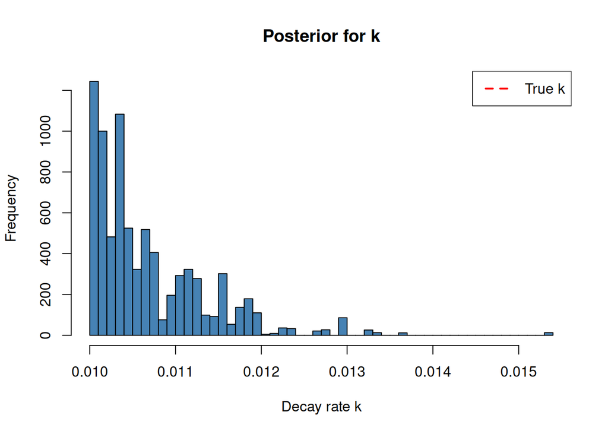

```r
# -----------------------------------------------------------------------------
# SIMPLE METROPOLIS-HASTINGS
# -----------------------------------------------------------------------------

simple_mcmc <- function(data, n_iter = 10000) {
  chain <- numeric(n_iter)
  current_k <- 0.3

  # Pre-compute ODE for current_k
  params <- c(Q = 1, V = 10, C_in = 1, k = current_k)
  out <- ode(y = c(C = 0), times = data$time, func = cstr_model, parms = params)
  current_error <- sum((data$C_obs - out[, "C"])^2)

  for (i in 1:n_iter) {
    # Propose new k
    proposed_k <- current_k + rnorm(1, 0, 0.03)

    # Keep in bounds
    if (proposed_k < 0.01 || proposed_k > 1) {
      chain[i] <- current_k
      next
    }

    # Run ODE with proposed k
    params["k"] <- proposed_k
    out <- ode(y = c(C = 0), times = data$time, func = cstr_model, parms = params)
    proposed_error <- sum((data$C_obs - out[, "C"])^2)

    # Accept or reject
    if (runif(1) < exp(-(proposed_error - current_error)/0.01)) {
      current_k <- proposed_k
      current_error <- proposed_error
    }

    chain[i] <- current_k
  }

  return(chain)
}

# Run it
posterior_k <- simple_mcmc(observations)

# Visualize
hist(posterior_k[2000:10000], breaks = 50, main = "Posterior for k",
     xlab = "Decay rate k", col = "steelblue")
abline(v = true_params["k"], col = "red", lwd = 2, lty = 2)
legend("topright", legend = "True k", col = "red", lty = 2, lwd = 2)
```

## Stan Code

```r
library(rstan)

# Stan code with ODE integration
stan_code <- "
functions {
  real[] cstr_model(real t, real[] y, real[] params, real[] x_r, int[] x_i) {
    real k = params[1];
    real C = y[1];
    real dC_dt = -k * C;
    return {dC_dt};
  }
}
data {
  int<lower=0> N;
  real t0;
  real ts[N];
  real y_obs[N];
}
parameters {
  real<lower=0, upper=1> k;
  real<lower=0> sigma;
}
model {
  real y_hat[N, 1];
  real y0[1] = {y_obs[1]};

  // Priors
  k ~ beta(1, 1);
  sigma ~ exponential(1);

  // Solve ODE
  y_hat = integrate_ode_rk45(cstr_model, y0, t0, ts, {k}, rep_array(0.0, 0), rep_array(0, 0));

  // Likelihood
  for (i in 1:N) {
    y_obs[i] ~ normal(y_hat[i, 1], sigma);
  }
}
"

# Fit the model
fit <- stan(model_code = stan_code,
            data = list(N = nrow(observations),
                        t0 = 0,
                        ts = observations$time,
                        y_obs = observations$C_obs),
            iter = 2000, chains = 4)

# --- Diagnostics ---
print(fit, pars = c("k", "sigma"))
traceplot(fit, pars = c("k", "sigma"))

posterior <- as.data.frame(extract(fit, pars = c("k", "sigma")))
hist(posterior$k, breaks = 50, col = "steelblue",
     main = "Stan posterior for k", xlab = "k")
abline(v = true_params["k"], col = "red", lwd = 2, lty = 2)
```